# my Q1

HaoLi

5/7/2021

##data description: The data is about what skills are needed most in different industries ## Question1. Which skill category is most common across all Industry Sections and how does it vary between each section?

| isic_section_name | mydat$skill_group_category | n |
| --- | --- | --- |
| Professional scientific and technical activities | Specialized Industry Skills | 387 |
| Information and communication | Tech Skills | 307 |
| Professional scientific and technical activities | Business Skills | 273 |
| Arts, entertainment and recreation | Specialized Industry Skills | 266 |
| Manufacturing | Specialized Industry Skills | 228 |
| Manufacturing | Business Skills | 215 |
| Professional scientific and technical activities | Tech Skills | 205 |
| Professional scientific and technical activities | Soft Skills | 202 |
| Information and communication | Specialized Industry Skills | 185 |
| Financial and insurance activities | Business Skills | 184 |

[output cut: 19 more lines]

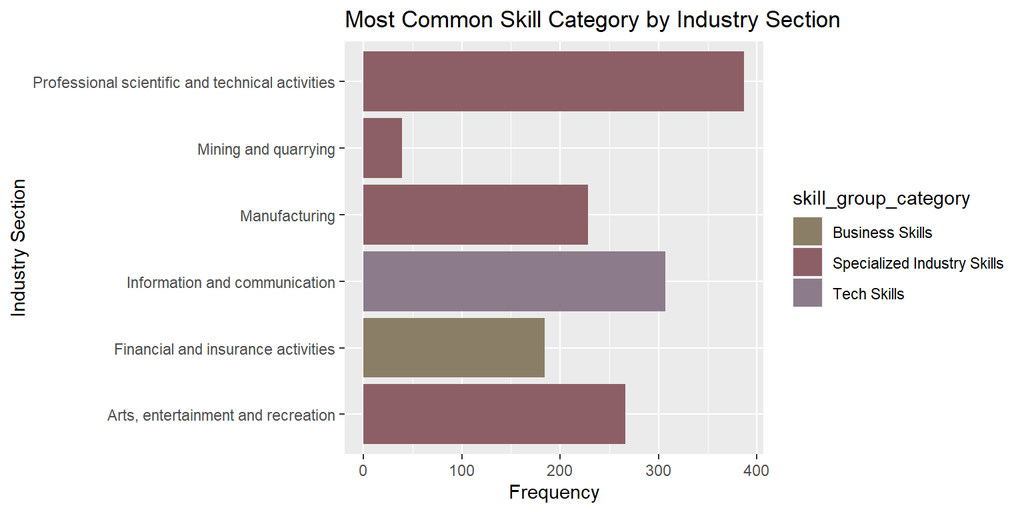

From the bar chart above, we can see the most common skill category within each industry section. Specialized Industry Skills are the most common skill category in 4 out of 6 industry sections. Tech skills are the most common within Information and Communication, Business Skills are the most common within Financial and Insurance Activities.

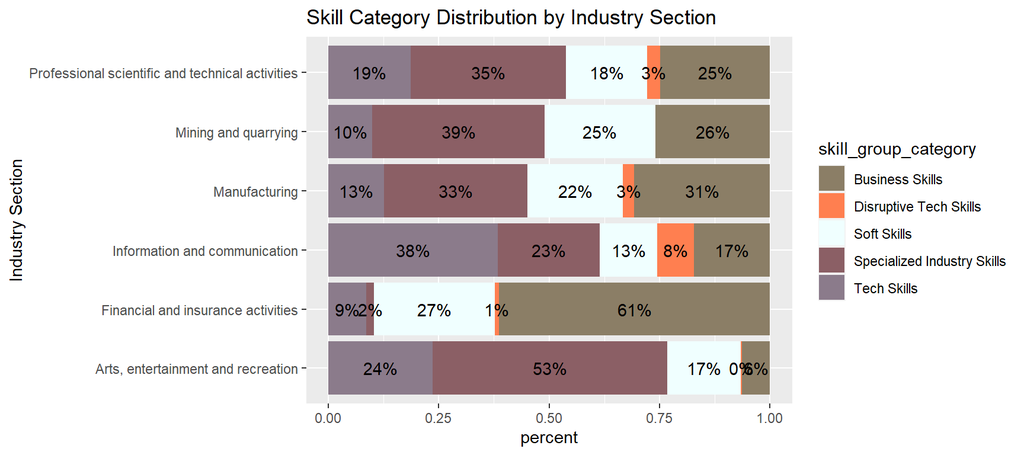

The above 100% stacked bar chart shows the skill category distribution within each industry section. While 4 out of 6 industry sections have a similar skill category distribution, Financial & Insurance Activities and Arts, Entertainment & Recreation have a rather different skill category distribution. Business skills are greatly needed (61%) while Tech skills are much less needed comparably for Financial industry. Specialized skills(53%) and Tech skills(24%) are majorly needed for Arts and Entertainment industry while Business skills (6%) and Disruptive Tech skills (0)are the least needed types for the industry section.